# Final Data Science Math Presentation

Dhananjay Kumar

August 11, 2016

#### My first Random Variable is Distance

```r
#Random variable X = Distance
dist <-hflights$Distance
```

```r
summary(dist)
```

```
##    Min. 1st Qu.  Median    Mean 3rd Qu.    Max.
##    79.0   376.0   809.0   787.8  1042.0  3904.0
```

#### My second variable is Arrival Delay. The Y variable is skewed to right as seen in summary(aDel)

```r
# Random variable Y = Arrival Delay
aDel <-hflights$ArrDelay
summary(aDel)
```

```
##    Min. 1st Qu.  Median    Mean 3rd Qu.    Max.    NA's
## -70.000  -8.000   0.000   7.094  11.000 978.000    3622
```

```r
# Skewed right
```

#### Using below formula, I am calculating 3d quartile of x i.e Distance and 2d quartile of y i.e Arrival Delay

```r
# x <- distance, 75 percentile
x<-quantile(dist)["75%"]
# y <- arr delay, 50 percentile
y<-quantile(aDel,na.rm = TRUE)["50%"]
```

#### 1. Part a) Probability P(X>x | Y>y)

```r
total<-nrow(hflights)

#a.P(X>x|Y>y)
xg_yg<-nrow(subset(hflights,dist>x & aDel>y))
yg<-nrow(subset(hflights,aDel>y))
p1<-xg_yg/total
p2<-yg/total
a<-p1/p2
a
```

```
## [1] 0.2502806
```

#### Analysis: The probability of a distance to be above third quartile given that the arrival delay is greater than 2d quartile, is 0.2502806

#### 2. Part b) Probability P(X>x, Y>y)

```r
#b. P(X>x,Y>y)
xg<-nrow(subset(hflights,dist>x))
yg<-nrow(subset(hflights,aDel>y))
p3 <-xg/total
p4<-yg/total
b<-p3*p4
b
```

```
## [1] 0.1171846
```

#### Analysis:The probability of a distance to be greater than third quartile and the arrival delay is greater than 2d quartile, is 0.1171846

```r
xl_yl<-nrow(subset(hflights,dist<x & aDel>y))
p5<-xl_yl/total
c<-p5/p4
c
```

```
## [1] 0.7417321
```

#### Analysis:The probability of a distance to be below third quartile given that the arrival delay is greater than 2d quartile, is 0.7417321

#### 4. Create and Fill Table

```r
#Fill the table values
c11<-nrow(subset(hflights,dist<=x & aDel<=y))
c12<-nrow(subset(hflights,dist<=x & aDel>y))
c13<-c11+c12
c21<-nrow(subset(hflights,dist>x & aDel<=y))
c22<-nrow(subset(hflights,dist>x & aDel>y))
c23<-c21+c22
c31<-c11+c21
c32<-c12+c22
c33<-c13+c23

tabValues<- matrix(c(c11,c12,c13,c21,c22,c23,c31,c32,c33),3,3)
colnames(tabValues) <- c("<=2d quartile",">2d quartile","Total")
rownames(tabValues) <- c('<=3d quartile', '>3d quartile','Total')
tabValues
```

[output not shown]

#### Question: Does splitting the data in this fashion make them independent?

#### Analysis: It is difficult to comment by just looking at the data, whether splitting has made them independent.

#### 5. Check P(A|B) = P(A).P(B)

```r
# Check P(A|B) = P(A).P(B)
A<-xg
B<-yg
p6=p1/p4
p7=p3*p4
check<-(p6==p7)
check
```

```
## [1] FALSE
```

#### Analysis: Mathematically P(A|B) NE P(A).P(B)

#### 6. Chi-square test for independence

```r
tbl = table(hflights$Distance, hflights$ArrDelay)
chisq.test(tbl)
```

```
##
##  Pearson's Chi-squared test
##
## data:  tbl
## X-squared = 99671, df = 72996, p-value < 2.2e-16
```

#### Analysis: p value 2.2e-16 is very small, so rejecting null hypothesis, meaning,there is relationship b/w distance and arrival delay

#### Part 2 DESCRIPTIVE AND INFERENTIAL STATISTICS

#### univariate descriptive of statistics (Summary)

```r
summary(dist)
```

```
##    Min. 1st Qu.  Median    Mean 3rd Qu.    Max.
##    79.0   376.0   809.0   787.8  1042.0  3904.0
```

```r
summary(aDel)
```

```
##    Min. 1st Qu.  Median    Mean 3rd Qu.    Max.    NA's
## -70.000  -8.000   0.000   7.094  11.000 978.000    3622
```

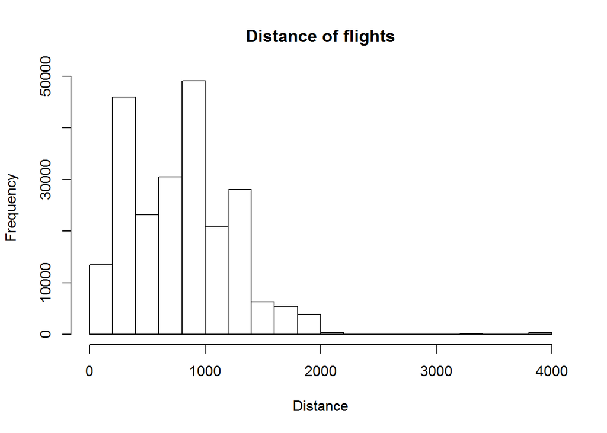

```r
# Histogram
hist(hflights$Distance,xlab= "Distance", main = "Distance of flights")
```

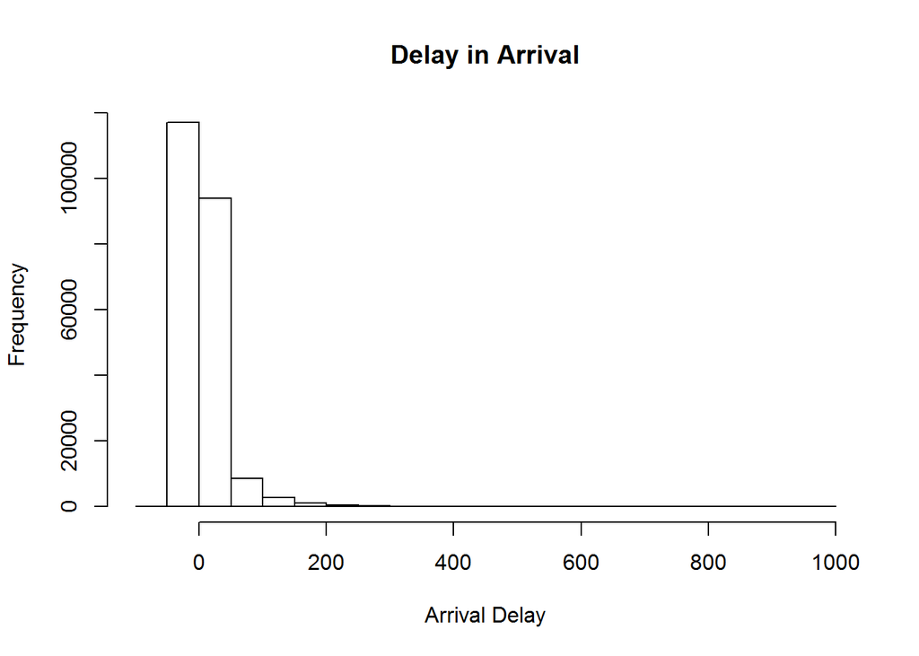

```r
hist(hflights$ArrDelay,xlab= "Arrival Delay", main = "Delay in Arrival")
```

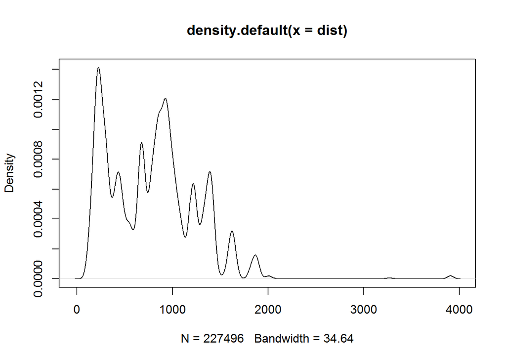

```r
# Density plot
d1 <- density(dist)
plot(d1)
```

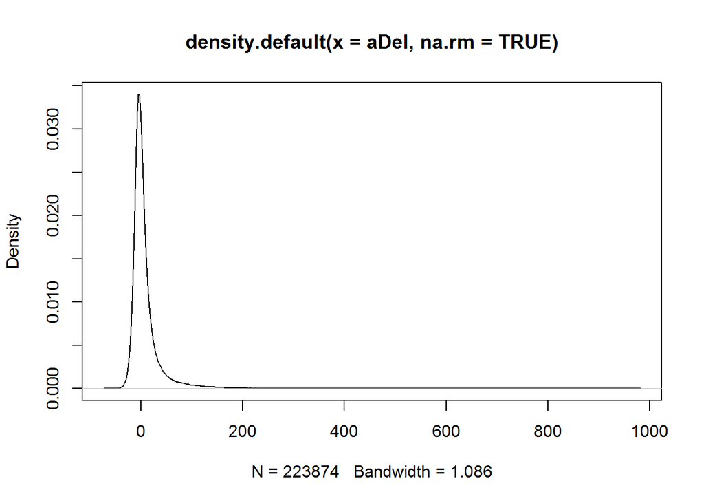

```r
d2 <-density(aDel, na.rm = TRUE)
plot(d2)
```

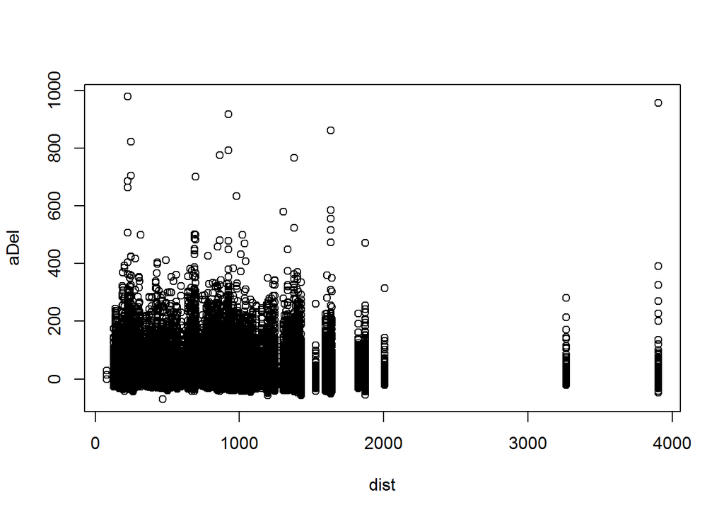

```r
# Scatter plot 1
plot(dist,aDel)
```

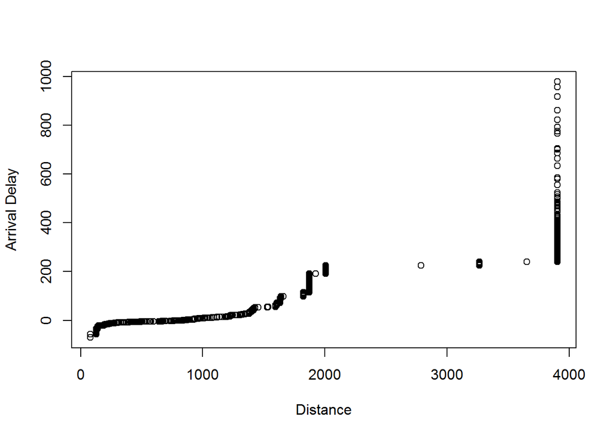

```r
#  Plot 2
qqplot(dist,aDel, xlab="Distance", ylab="Arrival Delay")
```

#### 95% CI for the difference of the two means

```r
t.test(dist, aDel)
```

```
##
##  Welch Two Sample t-test
##
## data:  dist and aDel
## t = 818.85, df = 229610, p-value < 2.2e-16
## alternative hypothesis: true difference in means is not equal to 0
## 95 percent confidence interval:
##  778.8203 782.5575
## sample estimates:
##  mean of x  mean of y
## 787.783245   7.094334
```

#### Correlation Matrix

```r
# Correlation matrix
Dist_aDelay<- hflights[,c("Distance","ArrDelay")]
Dist_aDelay <- Dist_aDelay[complete.cases(Dist_aDelay), ]
mat<-cor(Dist_aDelay)
mat
```

```
##              Distance     ArrDelay
## Distance  1.000000000 -0.004434254
## ArrDelay -0.004434254  1.000000000
```

#### Analysis: Correlation matrix shows their is a slight negative correlation between distance and arrival delay

#### Test the hypothesis that the correlation b/w these variables is 0 and provide a 99% confidence interval ?

```r
cor.test(dist,aDel, method = "pearson" , conf.level = 0.99)
```

```
##
##  Pearson's product-moment correlation
##
## data:  dist and aDel
## t = -2.0981, df = 223870, p-value = 0.0359
## alternative hypothesis: true correlation is not equal to 0
## 99 percent confidence interval:
##  -0.009877962  0.001009717
## sample estimates:
##          cor
## -0.004434254
```

#### Part 3 LINEAR ALGEBRA AND CORRELATION

#### Inverse correlation matrix

```r
inv<-solve(mat)
inv
```

```
##             Distance    ArrDelay
## Distance 1.000019663 0.004434341
## ArrDelay 0.004434341 1.000019663
```

#### Multiply correlation matrix with precision matrix

```r
matrix1 <-mat  %*% inv
matrix2<- inv %*% mat
matrix1
```

```
##               Distance ArrDelay
## Distance  1.000000e+00        0
## ArrDelay -8.673617e-19        1
```

```r
matrix2
```

```
##               Distance ArrDelay
## Distance  1.000000e+00        0
## ArrDelay -8.673617e-19        1
```

#### Analysis: The correlation matrix shows a negative correlation between distance and arrrival delay, meaning when distance increases arrival delay decreases and vice versa. But this correlation is very small(-0.004434254)

#### Part 4. CALCULUS BASED PROBABILITY AND STATISTICS

#### # For variable skewed to right, shift so that the min value is above 0. Arr Delay is skewed right

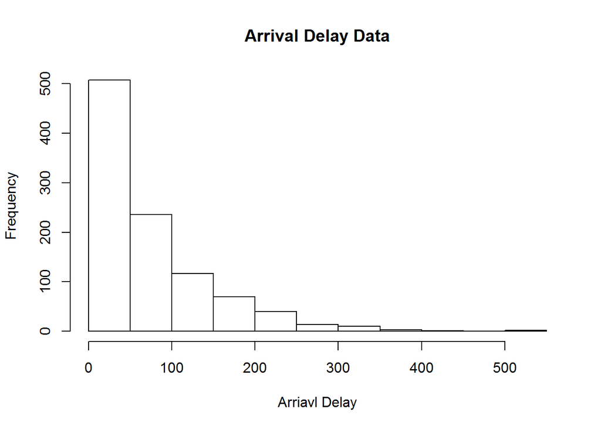

```r
# For variable skewed to right, shift so that the min value is above 0.
# Arr Delay is skewed right
min_aDel <- min(aDel,na.rm = TRUE)
# The min value is -70
aDel_new<-na.omit(aDel + 71)

# Fit exponential probability function and calculate lambda
expdist<-fitdistr(aDel_new,"exponential")
l<-expdist$estimate
samp<-rexp(1000, l)

#Plot Histogram
hist(samp,xlab= "Arriavl Delay", main = "Arrival Delay Data")
```

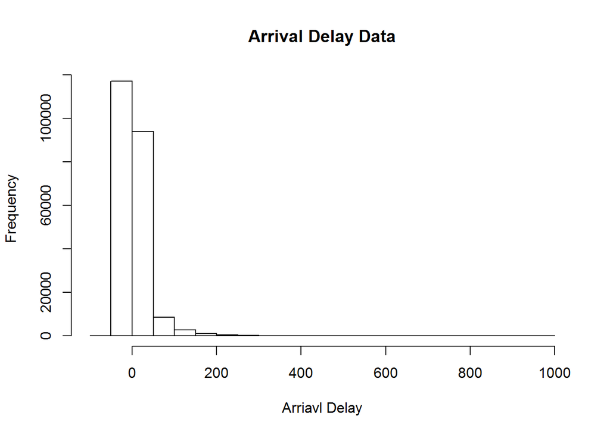

```r
hist(aDel,xlab= "Arriavl Delay", main = "Arrival Delay Data")
```

##### Analysis: comparing the histograms we see the data is still positively skewed as in the original dataset, but with the estimations, it is more spread out.

#### Using the exponential pdf, find the 5th and 95th percentiles using the cumulative distribution function (CDF).

```r
qexp(0.05,rate = l) #  4.005716
```

```
## [1] 4.005716
```

```r
qexp(0.95,rate = l) # 233.9497
```

```
## [1] 233.9497
```

```r
#95% confidence interval from the empirical data, assuming normality.
error<-qnorm(0.975)*expdist$sd/sqrt(expdist$n)
left<- l-error  # 0.01280491
right<-l+error  # 0.01280514

#5th percentile and 95th percentile of the data
quantile(aDel, c(.05, .95),na.rm = TRUE)
```

```
##  5% 95%
## -18  57
```

```r
# 5% 95%
#-18  57
```

#### Analysis:There is a considerable difference between the empirical data and the original data